# Data Structures in R & Python

Lecture 06

Dr. Colin Rundel

# Python classes

## Basic syntax

A `class` statement bundles attributes (data) and methods (functions) into a new type. Methods receive the instance as their first argument, conventionally named `self`.

```python
class rect:
  """An object representing a rectangle"""
  p1 = (0, 0)
  p2 = (1, 2)

  def area(self):
    return abs((self.p1[0] - self.p2[0]) *
               (self.p1[1] - self.p2[1]))

  def set_p1(self, p1):
    self.p1 = p1
```

```python
x = rect()
x.area()
```

```
2
```

```python
x.p1
```

```
(0, 0)
```

```python
x.set_p1((1, 1))
x.area()
```

```
0
```

```python
x.p2 = (3, 3)
x.area()
```

```
4
```

## `__init__`

Class construction, i.e. calling the class `rect()`, creates a new instance of the class its `__init__()` method.

```python
class rect:
  """An object representing a rectangle"""

  def __init__(self, p1=(0, 0), p2=(1, 1)):
    self.p1 = p1
    self.p2 = p2

  def area(self):
    return abs((self.p1[0] - self.p2[0]) *
               (self.p1[1] - self.p2[1]))
```

```python
rect().area()
```

```
1
```

```python
rect((0, 0), (3, 3)).area()
```

```
9
```

```python
z = rect(p1=(-1, -1))
z.p1
```

```
(-1, -1)
```

```python
z.p2
```

```
(1, 1)
```

Methods whose names start and end with double underscores (`__init__`, `__repr__`, …) are called “dunder” methods - Python calls them implicitly in specific situations.

## Class vs instance attributes

Attributes assigned in the class body are class attributes shared by every instance (useful for constants), while attributes assigned via `self` are instance attributes belonging to a specific object.

```python
class die:
  sides = 6

  def __init__(self, value=1):
    self.value = value
```

```python
d = die(3)
d.value
```

```
3
```

```python
d.sides
```

```
6
```

```python
die.sides
```

```
6
```

```python
die.value
```

```
AttributeError: type object 'die' has no attribute 'value'
```

```python
vars(d)
```

```
{'value': 3}
```

```python
[m for m in dir(d) if not m.startswith("__")]
```

```
['sides', 'value']
```

```python
die.sides = 3
d.sides
```

```
3
```

`dir()` lists all attributes and methods of an object (including inherited dunder methods), while `vars()` returns just the instance attributes as a `dict`.

## Mutate or return?

Python methods like `sort()` and `append()` modify the object in place and return `None`, while functions like `sorted()` return a new object and leave the original alone. R functions essentially always do the latter, so results must be assigned back to be kept.

```python
x = [3, 1, 2]
print( x.sort() )
```

```
None
```

```python
x
```

```
[1, 2, 3]
```

```python
x = [3, 1, 2]
sorted(x)
```

```
[1, 2, 3]
```

```python
x
```

```
[3, 1, 2]
```

```r
x = c(3, 1, 2)
sort(x)
```

```
[1] 1 2 3
```

```r
x
```

```
[1] 3 1 2
```

```r
x = sort(x)
x
```

```
[1] 1 2 3
```

## Method chaining

Returning `self` (or a new object) from a method allows calls to be chained, with each method operating on the result of the previous one. This plays the same role in Python that the pipe does in R.

```python
def set_p1(self, p1):
  self.p1 = p1
  return self

rect.set_p1 = set_p1
```

```python
( rect()
  .set_p1((-1, -1))
  .area()
)
```

```
4
```

```python
" Hello World ".strip().lower().split()
```

```
['hello', 'world']
```

Chaining in libraries like pandas works the same way, though most of those methods return a new object rather than modifying `self` in place.

## `__str__` and `__repr__`

Every object has a default string representation, which can be overridden these dunder methods:

```python
rect()
```

```
<__main__.rect object at 0x1122ef5c0>
```

```python
print(rect())
```

```
<__main__.rect object at 0x11233f2f0>
```

- `__repr__()` - returns an unambiguous representation (ideally valid Python).
- `__str__()` - used by `print()` and `str()`, falls back to `__repr__()`.

```python
def rect_repr(self):
  return f"rect({self.p1}, {self.p2})"

rect.__repr__ = rect_repr
```

```python
rect()
```

```
rect((0, 0), (1, 1))
```

```python
print(rect())
```

```
rect((0, 0), (1, 1))
```

```python
[rect(), rect((1, 1), (2, 2))]
```

```
[rect((0, 0), (1, 1)), rect((1, 1), (2, 2))]
```

## Other special methods

Operators and built-in functions also dispatch to special methods - this is the mechanism behind the operator overloading we’ve seen previously.

```python
def rect_eq(self, other):
  return (self.p1 == other.p1 and
          self.p2 == other.p2)

rect.__eq__ = rect_eq

def rect_contains(self, pt):
  return all(
    min(a, b) <= x <= max(a, b)
    for a, b, x in zip(self.p1, self.p2, pt)
  )

rect.__contains__ = rect_contains
```

```python
rect()
```

```
rect((0, 0), (1, 1))
```

```python
rect() == rect()
```

```
True
```

```python
rect() == rect((1, 1), (2, 2))
```

```
False
```

```python
(0.5, 0.5) in rect()
```

```
True
```

```python
(2, 2) in rect()
```

```
False
```

See the [data model](https://docs.python.org/3/reference/datamodel.html#special-method-names) docs for the full list, including `__eq__`, `__len__`, `__getitem__`, `__add__`, and `__lt__`.

## Inheritance

A class can inherit from another class(es), gaining all of its attributes and methods. The subclass can add new methods and override existing ones - `super()` gives access to the parent’s version.

```python
class square(rect):
  def __init__(self, p1=(0, 0), l=1):
    if not isinstance(l, (int, float)):
      raise TypeError("l must be a number")
    self.l = l
    super().__init__(p1, (p1[0] + l, p1[1] + l))

  def __repr__(self):
    return f"square({self.p1}, {self.l})"
```

```python
s = square((1, 1), 2)
s
```

```
square((1, 1), 2)
```

```python
s.p2
```

```
(3, 3)
```

```python
s.area()
```

```
4
```

```python
(2, 2) in s
```

```
True
```

```python
square(l="a")
```

```
TypeError: l must be a number
```

## `isinstance()` vs `type()`

`isinstance()` respects inheritance while `type()` reports the exact class - the former is almost always what you want when validating inputs, but be aware of what type inherits what.

```python
isinstance(s, square)
```

```
True
```

```python
isinstance(s, rect)
```

```
True
```

```python
type(s) is rect
```

```
False
```

```python
isinstance(3, (int, float))
```

```
True
```

```python
isinstance("3", (int, float))
```

```
False
```

```python
isinstance(True, int)
```

```
True
```

```python
type(True) is int
```

```
False
```

```python
bool.__mro__
```

```
(<class 'bool'>, <class 'int'>, <class 'object'>)
```

# Tuples

## Tuples

Python tuples are *heterogeneous*, *ordered*, **immutable** containers - lists whose contents cannot be changed. R has no tuple type, a list (or an atomic vector) is used instead.

```python
(1, 2, 3)
```

```
(1, 2, 3)
```

```python
(1, True, "abc")
```

```
(1, True, 'abc')
```

```python
type( (1) )
```

```
<class 'int'>
```

```python
type( (1,) )
```

```
<class 'tuple'>
```

```python
x = (1, 2, 3)
x[2] = 5
```

```
TypeError: 'tuple' object does not support item assignment
```

```python
x = (1, [2, 3])
x[1].append(4)
x
```

```
(1, [2, 3, 4])
```

It is the *comma* that creates a tuple, not the parentheses - `(1)` is just the number 1 and a one element tuple must be written `(1,)`.

Immutability is *shallow*, a mutable object stored in a tuple can still be modified in place.

## Unpacking

Assigning a sequence to several names at once *unpacks* it. A name prefixed with `*` collects any remaining values into a list.

```python
def minmax(x):
    return min(x), max(x)
minmax([3, 1, 2])
```

```
(1, 3)
```

```python
lo, hi = minmax([3, 1, 2])
print(lo, hi)
```

```
1 3
```

```python
x, y = 1, 2
x, y = y, x
x, y
```

```
(2, 1)
```

```python
first, *rest = range(6)
first
```

```
0
```

```python
rest
```

```
[1, 2, 3, 4, 5]
```

```python
pairs = [("a", 1), ("b", 2)]
for i, (k, v) in enumerate(pairs):
    print(i, k, v)
```

```
0 a 1
1 b 2
```

The number of names must match the length of the sequence (`x, y = [1, 2, 3]` is a `ValueError`) unless one of them is starred.

# Dictionaries

## Dictionaries

Python `dict`s are *mutable* containers of `key: value` pairs, designed for the efficient lookup of a value by its key. The closest (common) R analog is a named list (or a named atomic vector).

```python
{"abc": 123, "def": 456}
```

```
{'abc': 123, 'def': 456}
```

```python
dict([("abc", 123), ("def", 456)])
```

```
{'abc': 123, 'def': 456}
```

```python
dict(abc=123, hello=456)
```

```
{'abc': 123, 'hello': 456}
```

```python
dict(zip(["abc", "def"], [1, 2]))
```

```
{'abc': 1, 'def': 2}
```

```r
list(abc = 123, def = 456)
```

```
$abc
[1] 123

$def
[1] 456
```

```r
c(abc = 123, def = 456)
```

```
abc def
123 456
```

Since Python 3.7 dictionaries preserve insertion order. The keyword form of `dict()` only works for keys that are valid Python names (e.g. `def` is a reserved word).

## Keys must be hashable

Dictionary keys and set elements must be hashable and values can be anything.

| Hashable | Unhashable |
| --- | --- |
| `int`, `float`, `bool`, `complex` | `list` |
| `str`, `bytes`, `range` | `dict` |
| `None`, `frozenset` | `set` |
| `tuple` if all its elements are hashable | `tuple` containing an unhashable element |

Lists are unhashable, so neither a list nor a tuple containing a list can be a key:

```python
{[1]: "bad"}
```

```
TypeError: cannot use 'list' as a dict key (unhashable type: 'list')
```

```python
{(1, [2]): "bad"}
```

```
TypeError: cannot use 'tuple' as a dict key (unhashable type: 'list')
```

You can always coerce a list to a tuple (but this is shallow),

```python
{tuple([1]): "Okay"}
```

```
{(1,): 'Okay'}
```

```python
{(1, tuple([2])): "Okay"}
```

```
{(1, (2,)): 'Okay'}
```

## Lookup

Key lookup is via `[]`, if the key is missing a `KeyError` is raised. Alternatively, use `.get()` with a default. `in` checks for the presence of a key.

```python
x = {1: "abc", "y": "hello", (1, 1): 3.14}
x[1]
```

```
'abc'
```

```python
x[(1, 1)]
```

```
3.14
```

```python
x["def"]
```

```
KeyError: 'def'
```

```python
"y" in x
```

```
True
```

```python
"hello" in x
```

```
False
```

```python
print( x.get("def") )
```

```
None
```

```python
x.get("def", 0)
```

```
0
```

## Insert, replace, remove

Assigning to `d[key]` inserts or replaces a value for that key. `del` and `.pop()` remove key & value.

```python
x = {1: "abc", "y": "hello"}
x["def"] = -1
x["y"] = "goodbye"
x
```

```
{1: 'abc', 'y': 'goodbye', 'def': -1}
```

```python
del x[1]
x.pop("def")
```

```
-1
```

```python
x["y"] = None
x
```

```
{'y': None}
```

```r
y = list(abc = 123, def = 456)
y$ghi = -1
y$def = "goodbye"
str(y)
```

```
List of 3
 $ abc: num 123
 $ def: chr "goodbye"
 $ ghi: num -1
```

```r
y$abc = NULL
str(y)
```

```
List of 2
 $ def: chr "goodbye"
 $ ghi: num -1
```

Unlike R - assigning `None` does *not* remove a key.

## Methods & iteration

Iterating over a `dict` yields its keys - use `.items()` to get keys and values together.

```python
x = {1: "abc", "y": "hello"}
```

```python
x.keys()
```

```
dict_keys([1, 'y'])
```

```python
x.values()
```

```
dict_values(['abc', 'hello'])
```

```python
for k, v in x.items():
    print(k, "->", v)
```

```
1 -> abc
y -> hello
```

```python
x.items()
```

```
dict_items([(1, 'abc'), ('y', 'hello')])
```

```python
x | {"y": "goodbye", "w": 0}
```

```
{1: 'abc', 'y': 'goodbye', 'w': 0}
```

```python
x.update({"y": "goodbye", "w": 0})
x
```

```
{1: 'abc', 'y': 'goodbye', 'w': 0}
```

`.keys()`, `.values()`, and `.items()` return dynamic views of the dictionary rather than copies - see the [docs](https://docs.python.org/3/library/stdtypes.html#dictionary-view-objects).

`|` returns a *new* merged dictionary (right side wins), `.update()` merges in place.

## Exercise 1

Using the record from last lecture, complete these tasks in Python:

```python
person = {
  "firstName": "John",
  "lastName": "Smith",
  "age": 25,
  "address": {
    "streetAddress": "21 2nd Street",
    "city": "New York",
    "state": "NY",
    "postalCode": 10021
  },
  "phoneNumber": [
    { "type": "home",
      "number": "212 555-1239" },
    { "type": "fax",
      "number": "646 555-4567" }
  ]
}
```

- Extract the fax number.
- Add a `"mobile"` phone number and remove `age`.
- Write `phone(person, phone_type)` to return the requested number, or `None` if absent.

JSON uses `true`, `false`, and `null` where Python uses `True`, `False`, and `None`.

# Sets

## Sets

A `set` is a *mutable*, *unordered* collection of **unique** hashable elements - there are no positions, so the primary operation is membership testing with `in`.

```python
x = {1, 2, 3, 4, 1, 2}
x
```

```
{1, 2, 3, 4}
```

```python
set("mississippi")
```

```
{'p', 'i', 's', 'm'}
```

```python
3 in x
```

```
True
```

```python
x[0]
```

```
TypeError: 'set' object is not subscriptable
```

```python
x.add(9)
x.discard(8)
x.update([7, 8])
x
```

```
{1, 2, 3, 4, 7, 8, 9}
```

```python
x.remove(6)
```

```
KeyError: 6
```

```python
{1, 2, [1, 2]}
```

```
TypeError: cannot use 'list' as a set element (unhashable type: 'list')
```

`{}` creates an empty *dictionary*, an empty set must be written `set()`. `remove()` raises a `KeyError` if the element is absent while `discard()` does not, and iteration order is not guaranteed (use `sorted(x)` for a stable order).

## Set operations

Sets support the usual mathematical operations. R has no set type - any vector can be treated as one via `unique()` and the set functions.

```python
x = {1, 2, 3}
y = {2, 3, 4}
```

```python
x | y
```

```
{1, 2, 3, 4}
```

```python
x & y
```

```
{2, 3}
```

```python
x - y
```

```
{1}
```

```python
1 in x
```

```
True
```

```r
x = c(1, 2, 3, 1)
y = c(2, 3, 4)
```

```r
union(x, y)
```

```
[1] 1 2 3 4
```

```r
intersect(x, y)
```

```
[1] 2 3
```

```r
setdiff(x, y)
```

```
[1] 1
```

```r
1 %in% x
```

```
[1] TRUE
```

Python’s set methods (`x.union(y)`, `x.intersection(y)`, …) accept any iterable, the operators require sets on both sides. R’s set functions return unique values in order of first appearance.

# Algorithms & data structures

## Big-O notation

Big-O notation describes the *complexity* of an algorithm - how the time (or memory) required grows with the size of the input $n$. Only the fastest growing term matters (constant factors and lower order terms are dropped), so two algorithms with the same Big-O can still differ greatly in practice.

Since performance depends on the data we usually quote *average* or *worst case* complexity, and *amortized* complexity when an occasional expensive step is paid for by many cheap ones (e.g. growing a list).

| Complexity | Big-O |
| --- | --- |
| Constant | O($1$) |
| Logarithmic | O($\log n$) |
| Linear | O($n$) |
| Quasilinear | O($n \log n$) |
| Quadratic | O($n^2$) |
| Exponential | O($C^n$) |

## Under the hood

The containers in both languages are built from a handful of basic structures - knowing which is which explains what each container is good, and bad, at.

| Structure | Layout | R | Python |
| --- | --- | --- | --- |
| Array | contiguous block of same-sized values | materialized numeric vector | contiguous numeric `ndarray` |
| Array of pointers | contiguous block of *references* to objects | list | `list`, `tuple` |
| Linked list | nodes that each point to their neighbors | pairlist | `deque` (linked blocks) |
| Hash table | array indexed by `hash(key)` | environment | `dict`, `set` |

See [R Internals](https://cran.r-project.org/doc/manuals/r-release/R-ints.html) and [CPython Internals](https://github.com/zpoint/CPython-Internals) for the gory details.

## Vectors

Materialized numeric vectors in R and contiguous numeric NumPy arrays store fixed-size values together, giving O(1) element access. NumPy views can have gaps or reversed strides.

```r
object.size(numeric(1e6))
```

```
8000048 bytes
```

```r
object.size(integer(1e6))
```

```
4000048 bytes
```

```python
np.zeros(1_000_000).nbytes
```

```
8000000
```

```python
np.zeros(1_000_000, dtype="int64").nbytes
```

```
8000000
```

```python
np.zeros(1_000_000, dtype="int32").nbytes
```

```
4000000
```

R doubles use 8 bytes per element; integers use 4. `object.size()` includes object overhead; NumPy’s `.nbytes` counts only element storage.

## Growing a vector

Repeatedly appending with `c(x, i)` copies the existing elements each time, giving O($n^2$) work overall.

```r
n = 5e4
x = c()
system.time(
  for (i in seq_len(n)) x = c(x, i)
)
```

```
   user  system elapsed
  0.997   0.016   1.013
```

Indexed growth can reuse spare capacity, but still needs occasional copying. Preallocation avoids repeated growth.

```r
x = numeric()
system.time(
  for (i in seq_len(n)) x[i] = i
)
```

```
   user  system elapsed
  0.004   0.000   0.004
```

```r
x = numeric(n)
system.time(
  for (i in seq_len(n)) x[i] = i
)
```

```
   user  system elapsed
  0.002   0.000   0.002
```

## Array (Vector)

[interactive chart not shown]

https://visualgo.net/en/array - Materialized numeric R vectors and contiguous numeric NumPy arrays store same-typed values together. A Python `list` is a contiguous array of *pointers* to objects, which is why it can be heterogeneous and why it uses far more memory.

## Generic vectors

R and Python lists store references to objects. Elements can have different types and sizes, while indexing remains O(1). References and object headers add memory overhead.

- Numeric vector - values stored contiguously:

  ```
  [ 1.0 | 2.0 | 3.0 ]
  ```

- List - *references* stored contiguously

  ```
  [  P  |  P  |  P  ]
     ↓     ↓     ↓
     1   "abc"  TRUE
  ```

## deques

A `deque` (double-ended queue) supports O(1) additions and removals at either end. CPython stores it as a doubly linked chain of fixed-size blocks. Indexing is O(1) near either end and O(n) in the middle.

```python
from collections import deque
x = deque(range(3))
x.appendleft(-1)
x
```

```
deque([-1, 0, 1, 2])
```

```python
x.popleft()
```

```
-1
```

```python
x
```

```
deque([0, 1, 2])
```

```python
x = deque(range(3), maxlen=4)
x.append(10)
x.append(11)
x
```

```
deque([1, 2, 10, 11], maxlen=4)
```

```python
x.appendleft(-1)
x
```

```
deque([-1, 1, 2, 10], maxlen=4)
```

With `maxlen` set, adding to a full deque drops an element from the opposite end - a rolling window of the last $n$ items. `list.pop(0)` and `list.insert(0, v)` have to shift every remaining element.

## Linked list

[interactive chart not shown]

https://visualgo.net/en/list - CPython’s `deque` links blocks of elements. R uses *pairlists* (linked lists) internally for function arguments and attributes.

## Hashing

A hash table is an array of *buckets* - a key’s `hash()` picks its bucket, so lookup, insertion and deletion are O(1) on average with no scanning. Two keys landing in the same bucket is a *collision*, and the table is resized as it fills to keep collisions rare.

```python
hash(1), hash(1.0), hash(True)
```

```
(1, 1, 1)
```

```python
hash(2.5)
```

```
1152921504606846978
```

```python
hash((1, 2))
```

```
-3550055125485641917
```

```python
keys = (1, 9, 17, 2.5)
[hash(k) % 8 for k in keys]
```

```
[1, 1, 1, 2]
```

```r
h = new.env(size = 8L)
for (k in letters[1:5]) h[[k]] = k
str(env.profile(h))
```

```
List of 3
 $ size   : int 8
 $ nchains: int 5
 $ counts : int [1:8] 0 1 1 1 1 1 0 0
```

```r
for (k in letters[6:20]) h[[k]] = k
env.profile(h)$size
```

```
[1] 25
```

Equal keys must hash equally, which is why `1`, `1.0`, and `True` are the same `dict` key. String hashes are randomized per process, so `hash("abc")` (and the iteration order of a set of strings) changes between runs. `env.profile()` reports the bucket sizes of an environment’s table - R chains colliding keys within a bucket, CPython probes for another free slot.

## Hash table

[interactive chart not shown]

https://visualgo.net/en/hashtable - Python’s `dict` and `set` are hash tables, as are R environments. R’s `match()`, `%in%`, `unique()`, and `duplicated()` build a hash table of one argument, which is why they are fast.

## Operation costs

| Operation | `list` | `deque` | `dict` | `set` |
| --- | --- | --- | --- | --- |
| Copy | `.copy()`: O(n) | `.copy()`: O(n) | `.copy()`: O(n) | `.copy()`: O(n) |
| Get / set by index or key | `s[i]`: O(1) | `s[i]`: O(n) | `d[k]`: O(1) | — |
| Append / add | `.append(v)`: O(1)* | `.append(v)`: O(1) | `d[k] = v`: O(1)* | `.add(v)`: O(1)* |
| Pop from end / remove | `.pop()`: O(1)* | `.pop()`: O(1) | `.pop(k)`: O(1) | `.remove(v)`: O(1) |
| Insert at front | `.insert(0, v)`: O(n) | `.appendleft(v)`: O(1) | — | — |
| Remove from front | `.pop(0)`: O(n) | `.popleft()`: O(1) | — | — |
| Insert / delete in middle | O(n) | O(n) | — | — |
| Membership | `v in s`: O(n) | `v in s`: O(n) | `k in d`: O(1) | `v in s`: O(1) |

CPython costs for n elements.

*Amortized - list append and end pop, and hash table insertion, occasionally trigger a resize. Deque indexing is O(1) near either end. Hash table costs are averages that assume constant-cost hashing and equality, an individual operation can be O(n). Dictionary membership tests keys. See https://wiki.python.org/moin/TimeComplexity.

## Exercise 2

For each of the following, suggest a data structure in Python and R. Explain which operations your choice makes efficient, and state any assumptions.

- A collection of 100 integers used repeatedly in elementwise arithmetic.
- A queue (first in, first out) of customer records.
- A stack (first in, last out) of customer records.
- A count of word occurrences within a document.
- The heights of the bars in a histogram with even bin widths.
- Checking whether each of a million words is in a list of 50 stop words.

## Measuring vector growth

Reasoning about complexity tells you what to expect, measuring confirms it

- Code
- Linear
- Log

```r
grow_concat = function(n) {
  x = c()
  for (i in seq_len(n)) x = c(x, i)
}
grow_index = function(n) {
  x = numeric()
  for (i in seq_len(n)) x[i] = i
}
grow_prealloc = function(n) {
  x = numeric(n)
  for (i in seq_len(n)) x[i] = i
}
```

```r
res = bench::press(
  n = c(1e3, 2.5e3, 5e3, 1e4, 2.5e4, 5e4),
  bench::mark(
    concat   = grow_concat(n),
    index    = grow_index(n),
    prealloc = grow_prealloc(n),
    check = FALSE
  )
)
```

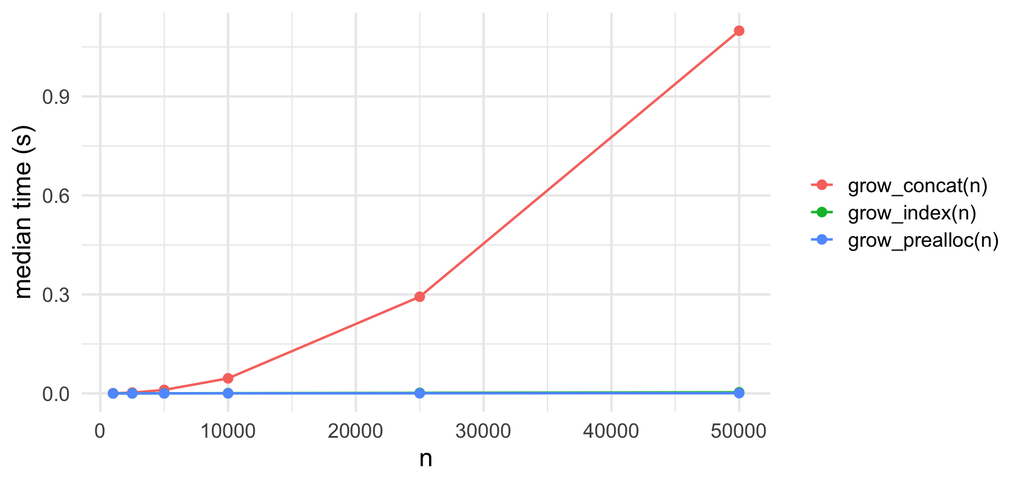

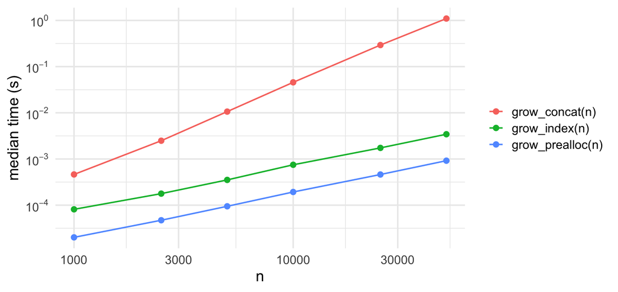

`bench::mark()` repeats each expression and reports the distribution of timings, `bench::press()` runs it over a grid of parameters.

# Comparing R & Python

## Container summary

| Python | Properties | R |
| --- | --- | --- |
| `list` | ordered, mutable, heterogeneous | `list()` |
| `tuple` | ordered, immutable, heterogeneous | `list()` or atomic vector (copy on modify) |
| `dict` | key lookup, mutable, insertion ordered | named `list()`, `new.env()` for hashing |
| `set` | unique, unordered, mutable | vector + `unique()`, `union()`, `%in%`, … |
| `deque` | fast at both ends | none (use a list or vector) |
| `range` | lazy integer sequence, immutable | `seq_len()`, `:` (often stored compactly via ALTREP) |
| NumPy `ndarray` | homogeneous, vectorized | atomic vector, matrix, array |

## Takeaways

- **Tuples** are immutable sequences—use them for fixed groups of values and unpacking.
- **Dictionaries** map hashable keys to values, with O(1) lookup on average. R offers named lists and hash-based environments.
- **Sets** provide O(1) membership on average and set algebra. In R, use `%in%`, `union()`, `intersect()`, and `setdiff()`.
- **Shallow copies** share nested objects. Use `deepcopy()` when nested objects need independent mutation.
- **Mutable defaults** are shared between calls. Use `None` and create the object inside the function.
- Choose containers for their operations: deques for queues, sets for membership, and preallocated R vectors when the size is known. Measure when performance matters.